# Ant Nutrient Supply Network Analysis and Visualization

Santiago Meneses

8/11/2022

```r
library(igraph)
```

Here we import the data from a .csv file using the function read_csv() from the package readr (contained in tidyverse). The dataset being imported here contains variables in columns and data points in rows for each variable. This will have to be transformed to be used in other packages such as igraph.

```r
Raw_casta <- read_csv(paste0(baseDir, "Bella_castaneus.csv"))
```

Next we need to select and filter the variables with the IDs of interacting individuals and make a new data frame. This data frame however has two variables containing raw data that must be summarized to add another variable: the frequency of interactions between two IDs. The result is a dataframe with only one row with interaction pairs and their frequency. Then we filter out all the zero values.

```r
grooming <- Raw_casta %>%
  dplyr::filter(!is.na(With), Event == "Grooming", With != "267", With != "47") %>%
  dplyr::select(Individual, With) %>%
  dplyr::count(Individual, With, name = "count", sort = TRUE)
```

[output not shown]

We need to create another data set with the meta data that characterizes the vertices of this network. We do this by summarizing the continuous variables and grouping by the categorical. We use group_by to then summarize individuals duration by behavior type.

```r
compare <- bind_cols(groom_nodes, groom_with)
```

[output not shown]

Next we begin to construct the networks

```r
E(groom_net)$weight <- E(groom_net$count)
```

[output not shown]

```r
#2) Number of Nodes
gorder(groom_net)
```

```
[1] 72
```

Then we calculate all measures of centrality for our network.

[figure not shown]

In this section we measure indicators of the network structure like network structure and assortativity.

```r
assortativity_nominal(share_net, types = values)
```

```
[1] 0.06201146
```

Network visualization.

```r
# 1) Plotting the sharing network with the degree centrality.

set.seed(1001)
pal <-  rainbow(length(unique(V(share_net)$Caste))) # vertex color assigned caste
plot.igraph(share_net, edge.color = 'black', vertex.label.cex = 0.5,
            vertex.color = pal[as.numeric(as.factor(vertex_attr(share_net, "Caste")))], vertex.size = sqrt(deg_share)*3,
            edge.width = E(share_net)$weight,layout = layout_nicely)

# 1.1) Plotting the grooming network with the degree centrality.
set.seed(1001)
pal <-  rainbow(length(unique(V(groom_net)$Caste))) # vertex color assigned caste
plot.igraph(groom_net, edge.color = 'black', vertex.label.cex = 0.5,
            vertex.color = pal[as.numeric(as.factor(vertex_attr(groom_net, "Caste")))],
            vertex.size = sqrt(deg_groom)*3,
            edge.width = E(groom_net)$weight, layout = layout_nicely)
```

[output not shown]

```r
# 2) Plotting network with eigenvalue centrality
set.seed(1001)
plot.igraph(share_net, edge.color = 'black', vertex.label.cex = 0.5,
            vertex.color = pal[as.numeric(as.factor(vertex_attr(share_net, "Caste")))],
            vertex.size = sqrt(eig_share)*10,
            edge.width = E(share_net)$weight,layout = layout_nicely)
```

[output not shown]

```r
# 3) Plotting network with betweenness centrality
set.seed(1001)
plot.igraph(share_net, edge.color = 'black', vertex.label.cex = 0.5,
            vertex.color = "green", vertex.size = sqrt(btw_share)/3,
            edge.width = E(share_net)$weight,layout = layout_nicely)
```

[output not shown]

Community Detection!

#1. Louvain Clustering.

```r
communities(groom_lc)
```

```
$`1`
[1] "230" "480" "76"  "136" "407"

$`2`
 [1] "259" "15"  "37"  "104" "106" "119" "174" "228" "236" "262" "335" "367" "448" "560"
[15] "604" "605" "627"

$`3`
[1] "397" "459" "67"  "72"  "166" "169" "366"

$`4`
[1] "643"

$`5`
[1] "0"

$`6`
[1] "11"  "293" "418" "528"

$`7`
[1] "46"

$`8`
[1] "77"

$`9`
[1] "98"  "484"

$`10`
[1] "108"

$`11`
[1] "160" "452" "453" "561"

$`12`
[1] "164"

$`13`
[1] "298" "321" "425" "481" "571" "630" "636" "646" "819"

```

[output cut: 8 more lines]

```

$`17`
[1] "422" "424" "428" "449" "458" "489" "539" "543" "656"

$`18`
[1] "529"

$`19`
[1] "564"

$`20`
[1] "565"

$`21`
[1] "594"
```

#2 Plotting the betweenness centrality network with the community detection.

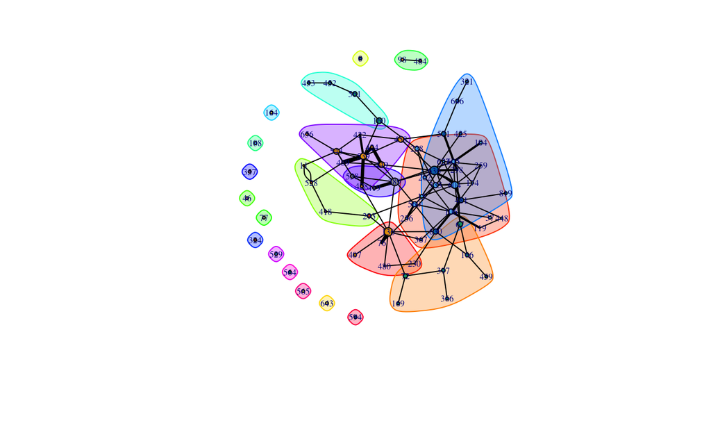